# moveVis group 2

Roshan, Jonathan, Mackenzie, Kenta

2023-04-11

# Introduction into moveVis

### 1. Background

- MoveViz is a package that consists of a set of tools used for visualizing movement data into animated trajectories
- Movement trajectories used for ggplots
- Spatial data containing x and y geolocation points for plots and maps is integrated with time stamp data (temporal data) forming spatio-temporal data
- Move, raster class inputs or movestack data added to baselayer map for ggplot frames
- MoveVis functions to animate movement trajectories using different time intervals
- Frames rendered into animations encoded as GIF or video file,

### 2. Application of moveVis

- Many of us in Biology programs conduct research consisting of track data for marine life such as sharks, dolphins and fish.
- Migration of cattle, bears, birds, snakes, lizards and endangered species.
- Population data i.e. human migration movement data across continents over time
- Visually explore and interpreting movement patterns
- Potential interactions of individuals with each other and their environment
- Climate data, tornados, storms, rain & wind, tracking major weather events
- Historical data, migration, climate, environmental
- Stock data
- Can be used to track sports races/events such as bike races, cars, marathons etc
- Time resolution could be 500 years for human migration or 5 seconds for bike race data

### 3. The 4 computational steps

- To produce a ggplot or video output containing animated movement data, 4 main functions must be carried out
- 1. preparing data, (b) creating frames, (c) adapting frames and (d) animating frames
- Each of which have sub functions within their category to further optimize the output features of the visual.
- There are additional features that function by manipulating and changing the data such as those in the tidyverse package

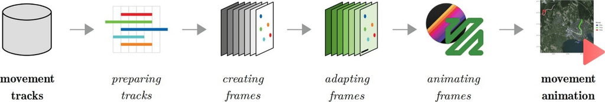

## ———————————————————————————————-

# Loading our Libraries

```r
library(tidyverse)
library(here)
library(tidytuesdayR)
library(lubridate)
```

To Download moveVis : **install.packages(“moveVis”)**

```r
# install.packages("moveVis")
library(moveVis)
```

# Loading our Sample data

To demostrate the abilities of this package, we will use Pet Cats UK dataset from TidyTuesday

Will use the “cats_uk” dataset

```r
tuesdata <- tidytuesdayR::tt_load(2023, week = 5)
cats_uk <- as.data.frame(tuesdata$cats_uk)
```

# Data Requirement

- unique sample identifier column
- time stamp (in a date format)
- x (longitude)
- y (latitude)

```r
glimpse(cats_uk)
```

```
## Rows: 18,215
## Columns: 11
## $ tag_id                   <chr> "Ares", "Ares", "Ares", "Ares", "Ares", "Ares…
## $ event_id                 <dbl> 3395610551, 3395610552, 3395610553, 339561055…
## $ visible                  <lgl> TRUE, TRUE, TRUE, TRUE, TRUE, TRUE, TRUE, TRU…
## $ timestamp                <dttm> 2017-06-24 01:03:57, 2017-06-24 01:11:20, 20…
## $ location_long            <dbl> -5.113851, -5.113851, -5.113730, -5.113774, -…
## $ location_lat             <dbl> 50.17032, 50.17032, 50.16988, 50.16983, 50.17…
## $ ground_speed             <dbl> 684, 936, 2340, 0, 4896, 504, 108, 504, 252, …
## $ height_above_ellipsoid   <dbl> 154.67, 154.67, 81.35, 67.82, 118.03, 123.07,…
## $ algorithm_marked_outlier <lgl> FALSE, FALSE, FALSE, FALSE, FALSE, FALSE, FAL…
## $ manually_marked_outlier  <lgl> FALSE, FALSE, FALSE, FALSE, FALSE, FALSE, FAL…
## $ study_name               <chr> "Pet Cats United Kingdom", "Pet Cats United K…
```

# Preparing Movement Tracks

### Cleaning the data

- Needs to be a times data
- Cannot have duplicated time stamp

```r
cats_uk <- cats_uk%>%
  mutate( timestamp = ymd_hms(timestamp)) %>%
  filter(tag_id %in% c("Athena","Ares", "Lola")) #simplify dataset to managable practice set
```

If there is duplicated timestamp, needs to be removed

```r
cats_uk <- cats_uk[!duplicated(cats_uk$timestamp),]
```

### Use a object called Move or moveStack

First have to convert a data.frame to move or moveStack using *df2move()*

Our required compnents of the data will be specified here

```r
cat <- df2move(cats_uk,  #df
        proj = "+init=epsg:4326 +proj=longlat +datum=WGS84 +no_defs +ellps=WGS84 +towgs84=0,0,0",  #type of projection
        x = "location_long",  #what are your x coord
        y = "location_lat",
        time = "timestamp", #what are the time, needs to be POSIXct
        track_id = "tag_id"
)

glimpse(cat)
```

```
## Formal class 'MoveStack' [package "move"] with 17 slots
##   ..@ trackId                : Factor w/ 3 levels "Ares","Athena",..: 1 1 1 1 1 1 1 1 1 1 ...
##   ..@ timestamps             : POSIXct[1:432], format: "2017-06-24 01:03:57" "2017-06-24 01:11:20" ...
##   ..@ idData                 :'data.frame':  3 obs. of  0 variables
##   ..@ sensor                 : Factor w/ 1 level "unknown": 1 1 1 1 1 1 1 1 1 1 ...
##   ..@ data                   :'data.frame':  432 obs. of  3 variables:
##   .. ..$ x   : num [1:432] -5.11 -5.11 -5.11 -5.11 -5.11 ...
##   .. ..$ y   : num [1:432] 50.2 50.2 50.2 50.2 50.2 ...
##   .. ..$ time: POSIXct[1:432], format: "2017-06-24 01:03:57" "2017-06-24 01:11:20" ...
##   ..@ coords.nrs             : num(0)
##   ..@ coords                 : num [1:432, 1:2] -5.11 -5.11 -5.11 -5.11 -5.11 ...
##   .. ..- attr(*, "dimnames")=List of 2
##   ..@ bbox                   : num [1:2, 1:2] -5.12 50.14 -5.07 50.17
##   .. ..- attr(*, "dimnames")=List of 2
##   ..@ proj4string            :Formal class 'CRS' [package "sp"] with 1 slot
##   ..@ trackIdUnUsedRecords   : Factor w/ 3 levels "Ares","Athena",..:
##   ..@ timestampsUnUsedRecords: NULL
##   ..@ sensorUnUsedRecords    : Factor w/ 1 level "unknown":
##   ..@ dataUnUsedRecords      :'data.frame':  0 obs. of  0 variables
##   ..@ dateCreation           : POSIXct[1:1], format: "2023-03-25 21:21:29"
##   ..@ study                  : chr(0)
##   ..@ citation               : chr(0)
##   ..@ license                : chr(0)
```

### Align time resolution

To be able to convert data into frames, it needs to be consistent time intervals

```r
m <- align_move(cat,
                res = 10, #specify resolution
                unit = "mins") #resolution unit

glimpse(m)
```

```
## Formal class 'MoveStack' [package "move"] with 17 slots
##   ..@ trackId                : Factor w/ 3 levels "Ares","Athena",..: 1 1 1 1 1 1 1 1 1 1 ...
##   ..@ timestamps             : POSIXct[1:2903], format: "2017-06-24 01:10:13" "2017-06-24 01:20:13" ...
##   .. ..- attr(*, "names")="Ares1" "Ares2" ...
##   ..@ idData                 :'data.frame':  3 obs. of  0 variables
##   ..@ sensor                 : Factor w/ 2 levels "unknown","interpolateTime": 2 2 2 2 2 2 2 2 2 2 ...
##   .. ..- attr(*, "names")= chr [1:2903] "Ares1" "Ares2" "Ares3" "Ares4" ...
##   ..@ data                   :'data.frame':  2903 obs. of  3 variables:
##   .. ..$ x   : num [1:2903] -5.11 -5.11 -5.11 -5.11 -5.11 ...
##   .. ..$ y   : num [1:2903] 50.2 50.2 50.2 50.2 50.2 ...
##   .. ..$ time: POSIXct[1:2903], format: "2017-06-24 01:10:13" "2017-06-24 01:20:13" ...
##   ..@ coords.nrs             : num(0)
##   ..@ coords                 : num [1:2903, 1:2] -5.11 -5.11 -5.11 -5.11 -5.11 ...
##   .. ..- attr(*, "dimnames")=List of 2
##   ..@ bbox                   : num [1:2, 1:2] -5.12 50.14 -5.07 50.17
##   .. ..- attr(*, "dimnames")=List of 2
##   ..@ proj4string            :Formal class 'CRS' [package "sp"] with 1 slot
##   ..@ trackIdUnUsedRecords   : Factor w/ 3 levels "Ares","Athena",..:
##   ..@ timestampsUnUsedRecords: NULL
##   ..@ sensorUnUsedRecords    : Factor w/ 2 levels "unknown","interpolateTime":
##   ..@ dataUnUsedRecords      :'data.frame':  0 obs. of  0 variables
##   ..@ dateCreation           : POSIXct[1:1], format: "2023-03-25 21:21:29"
##   ..@ study                  : chr(0)
##   ..@ citation               : chr(0)
##   ..@ license                : chr(0)
```